# Mini Insights from World Food Programme(version 1)

Boadiwaa

Created on January 24, 2022

### **Overview of Report**

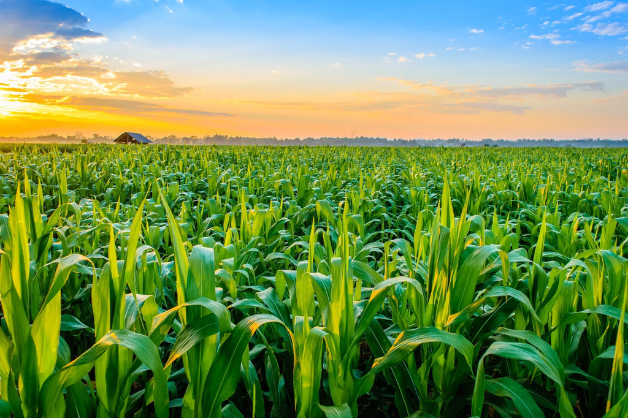

The `wfp`dataset shows the production of food commodities per year, town and region throughout Ghana. It contains detailed data on each unit of food commodity produced, including the type, price, and date(month,year)in which it was produced. There are 16,377 observations(entries) in all. This report answers the following questions:

- What are the most- and least- producing towns and regions?
- Which food commodities are produced the most, and least?
- What has been the trend of commodity prices?
- What are the most and least expensive commodities?
- What places have the most and least expensive commodity prices?
- What were the bumper and lean years?
- What regions lead the production of the best-performing commodity?

### Glimpse of the data:

```r
# Shows the first six rows of the dataset and a summary of the data
head(wfp)
```

```
## # A tibble: 6 x 9
##   region  town   comm              type      unit    year month price period
##   <chr>   <fct>  <chr>             <chr>     <chr>  <dbl> <fct> <dbl> <fct>
## 1 Ashanti Kumasi Maize - Wholesale Wholesale 100 KG  2009 Jan    44.5 2009 to 2~
## 2 Ashanti Kumasi Maize - Wholesale Wholesale 100 KG  2009 Feb    51.2 2009 to 2~
## 3 Ashanti Kumasi Maize - Wholesale Wholesale 100 KG  2009 Mar    55.8 2009 to 2~
## 4 Ashanti Kumasi Maize - Wholesale Wholesale 100 KG  2009 Apr    58   2009 to 2~
## 5 Ashanti Kumasi Maize - Wholesale Wholesale 100 KG  2009 May    69.6 2009 to 2~
## 6 Ashanti Kumasi Maize - Wholesale Wholesale 100 KG  2009 Jun    67   2009 to 2~
```

```r
summary(wfp)
```

```
##     region                town          comm               type
##  Length:16377       Kumasi  :1579   Length:16377       Length:16377
##  Class :character   Techiman:1558   Class :character   Class :character
##  Mode  :character   Accra   :1510   Mode  :character   Mode  :character
##                     Tamale  :1362
##                     Bolga   :1265
##                     Sunyani :1067
##                     (Other) :8036
##      unit                year          month          price
##  Length:16377       Min.   :2009   Feb    :1466   Min.   :   1.0
##  Class :character   1st Qu.:2012   Jun    :1445   1st Qu.:  52.0
##  Mode  :character   Median :2016   Jul    :1427   Median : 116.0
##                     Mean   :2016   Jan    :1415   Mean   : 159.0
##                     3rd Qu.:2020   Apr    :1415   3rd Qu.: 218.3
##                     Max.   :2021   Mar    :1404   Max.   :2960.8
##                                    (Other):7805
##           period
##  <2008       :   0
##  2009 to 2012:4466
##  2013 to 2016:4437
##  2017 to 2020:5979
##  2021+       :1495
##
##
```

### Best and worst producing towns and regions.

The table below shows the best and worst producing towns and regions. The towns and regions have been arranged in descending order of productivity. Kumasi, Ashanti Region is the highest producing town/city. However, overall, Brong Ahafo region tops in productivity.

Table 1: Production performance of towns and regions.

| Town | Region | Number of Entries |
| --- | --- | --- |
| Kumasi | Ashanti | 1579 |
| Techiman | Brong Ahafo | 1558 |
| Accra | Greater Accra | 1510 |
| Tamale | Northern | 1362 |
| Bolga | Upper East | 1265 |
| Sunyani | Brong Ahafo | 1067 |
| Sekondi/Takoradi | Western | 1030 |
| Koforidua | Eastern | 962 |
| Cape Coast | Central | 923 |
| Wa | Upper West | 889 |
| Tema | Greater Accra | 831 |
| Ejura | Ashanti | 810 |
| Mankessim | Central | 536 |
| Obuasi | Ashanti | 530 |
| Kintampo | Brong Ahafo | 449 |
| Ho | Volta | 426 |
| Hohoe | Volta | 204 |
| Yendi | Northern | 199 |
| Garu | Upper East | 154 |
| Other | Northern | 30 |
| Other | Volta | 20 |
| Other | Upper West | 17 |
| Other | Upper East | 14 |
| Other | Brong Ahafo | 12 |

Table 2: Ordering of regions in terms of productivity

| Region | Number of Entries |
| --- | --- |
| Brong Ahafo | 3086 |
| Ashanti | 2919 |
| Greater Accra | 2341 |
| Northern | 1591 |
| Central | 1459 |
| Upper East | 1433 |
| Western | 1030 |
| Eastern | 962 |
| Upper West | 906 |
| Volta | 650 |

### Most common and least common commodities.

Table 3: Count of Commodities

| Commodity | Count |
| --- | --- |
| Maize - Wholesale | 2043 |
| Cassava - Wholesale | 1852 |
| Yam - Wholesale | 1843 |
| Plantains (apentu) - Wholesale | 1817 |
| Rice (local) - Wholesale | 1793 |
| Rice (imported) - Wholesale | 1414 |
| Millet - Wholesale | 985 |
| Sorghum - Wholesale | 985 |
| Rice (paddy) - Wholesale | 355 |
| Plantains (apem) - Wholesale | 268 |

### Price trends

The line plot below shows the trend in prices of the top 3 commodities as stated above.It can be seen that with the exception of Cassava which has seen a slight drop in prices in recent years, the other top commodities have seen an increase in prices, with the sharpest increases seen in Yam.

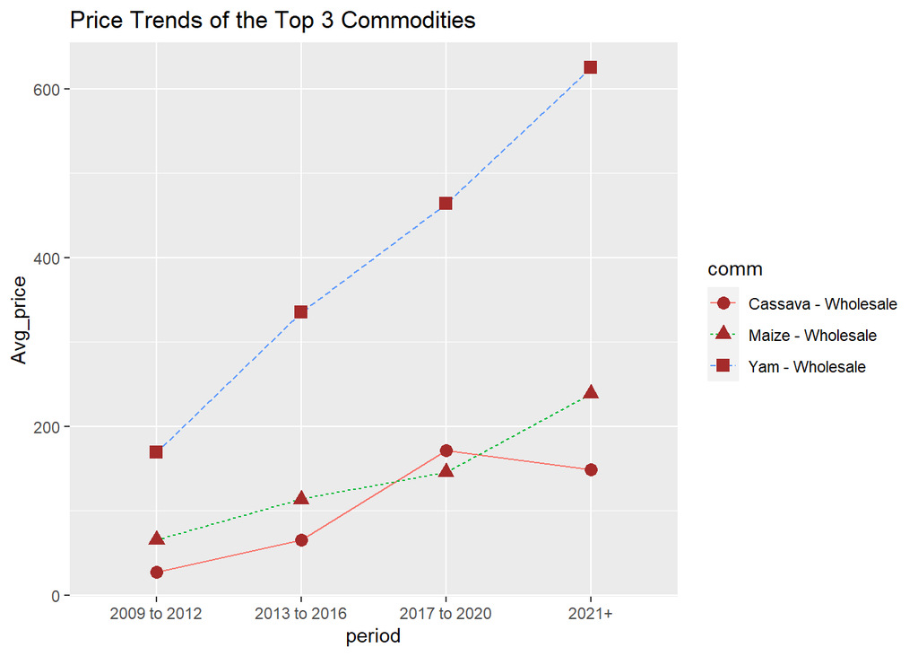

Figure 1: Trend of average price of the top 3 commodities

### Least expensive and most expensive commodities

The table below shows the overall average prices of food commodities, arranged from the most expensive to the least expensive.

Table 3: Average Commodity Prices

| Commodity | Average Price |
| --- | --- |
| Yam (puna) - Wholesale | 530.18462 |
| Peppers (fresh) - Wholesale | 352.88937 |
| Cowpeas (white) - Wholesale | 340.35473 |
| Fish (mackerel, fresh) - Wholesale | 339.11888 |
| Yam - Wholesale | 314.06321 |
| Gari - Wholesale | 275.56532 |
| Meat (chicken) - Wholesale | 260.60259 |
| Eggs - Wholesale | 225.53785 |
| Rice (imported) - Wholesale | 206.82694 |
| Eggplants - Wholesale | 191.19288 |
| Maize (yellow) - Wholesale | 184.82244 |
| Onions - Wholesale | 180.89043 |
| Millet - Wholesale | 173.88251 |
| Sorghum - Wholesale | 172.69538 |
| Meat (chicken, local) - Wholesale | 159.62119 |
| Soybeans - Wholesale | 132.10037 |
| Peppers (dried) - Wholesale | 127.54452 |
| Rice (local) - Wholesale | 121.11863 |
| Maize - Wholesale | 111.14477 |
| Tomatoes (local) - Wholesale | 110.07205 |
| Plantains (apem) - Wholesale | 107.68924 |
| Tomatoes (navrongo) - Wholesale | 90.81949 |
| Cassava - Wholesale | 80.30602 |
| Rice (paddy) - Wholesale | 77.43172 |
| Plantains (apentu) - Wholesale | 19.88733 |

### Regions and their average commodity prices

The table below shows which regions have the highest and lowest commodity prices.

Table 4: Average Prices per Region

| Region | Average Price |
| --- | --- |
| Western | 219.4383 |
| Greater Accra | 185.0866 |
| Eastern | 176.1153 |
| Central | 165.1503 |
| Brong Ahafo | 155.3640 |
| Ashanti | 150.5926 |
| Volta | 148.6460 |
| Upper East | 140.9061 |
| Northern | 135.5646 |
| Upper West | 112.2208 |

### Bumper and lean years

he table and graph below shows the yearly food production trend. It is interesting to note that the highest food production was seen in 2020 which is globally noted as the “Year of the COVID-19 Pandemic

Table 5: Productivity Per Year

| Year | Count |
| --- | --- |
| 2020 | 2795 |
| 2019 | 1675 |
| 2021 | 1495 |
| 2011 | 1163 |
| 2012 | 1148 |
| 2013 | 1147 |
| 2014 | 1137 |
| 2016 | 1124 |
| 2009 | 1085 |
| 2010 | 1070 |
| 2015 | 1029 |
| 2017 | 927 |
| 2018 | 582 |

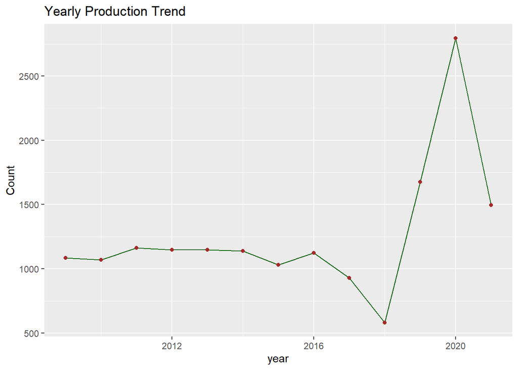

Figure 2: Trends of yearly productivity

### Areas with the highest production of maize.

The graph below shows the highest producers of maize, Region-wise:

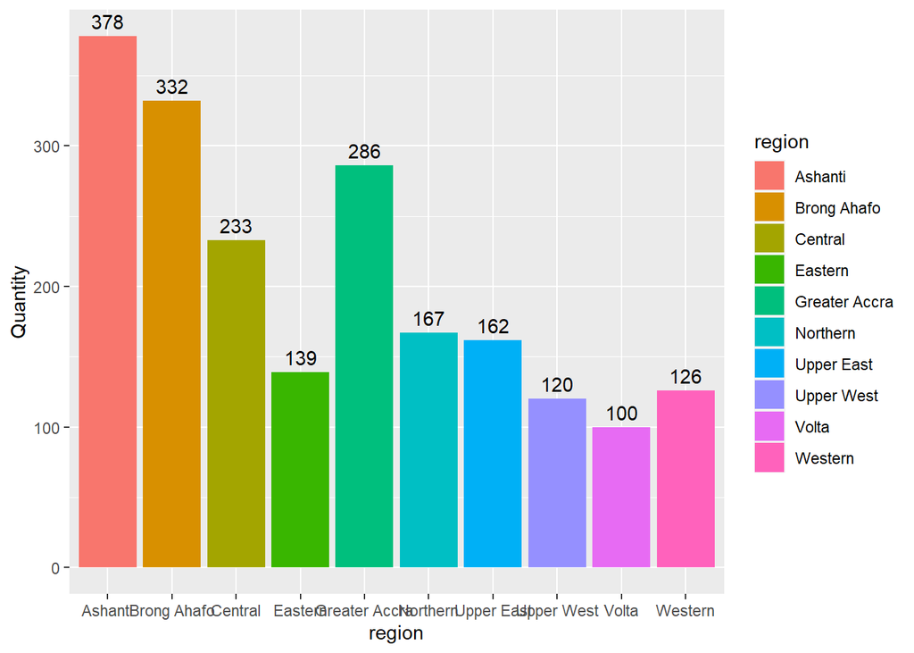

Figure 3: Maize production per region

**Thank you!**